# UDA Final Project

Author

Sophia Shi

## Introduction

The Florida Man phenomenon has become a famous internet meme, known for its bizarre, often absurd headlines that depict real-life events involving individuals in Florida. In this project, I will analyze the data of Florida Man and see if there is any interesting findings. By leveraging natural language processing techniques such as bigram analysis, topic modeling, and word cloud visualizations, I aim to explore the recurring themes and eccentric hedalines. The most important is to have fun.

## Data

The data is from scraping the news headlines from 5 different websites.

The websites are: 1. WCJB: (https://www.wcjb.com/news/crime/) 2. Reddit: (https://www.reddit.com/r/FloridaMan/) 3. Fox35 Orlando: (https://www.fox35orlando.com/tag/florida-man?page=1) 4. New York Post: (https://nypost.com/tag/florida-man/) 5. Newsweek: (https://www.newsweek.com/topic/florida-man)

### Step 1: Scrape Headlines from WCJB Crime

```python
import asyncio
from playwright.async_api import async_playwright
import pandas as pd

async def main():
    async with async_playwright() as p:
        # Launch a browser and set headless=False to see the browser
        browser = await p.chromium.launch(headless=False)
        # Open a new browser page
        page = await browser.new_page()

        # Navigate to the WCJB crime news page
        await page.goto("https://www.wcjb.com/news/crime/", timeout=60000)

        # Initialize an empty list to store headlines
        headlines_list = []

        # Click the 'Load More' button up to 20 times
        for i in range(20):
            # Extract all headlines on the current page
            for headline in await page.locator("span[data-tb-title]").all():
                title = await headline.inner_text()  # Get the text of each headline
                if title.strip():  # Ensure it's not an empty string
                    headlines_list.append({"headline": title.strip()})

            # Find the 'Load More' button
            load_more_button = page.get_by_role("button", name="Load More")
            # Check if the 'Load More' button is visible
            if await load_more_button.is_visible():
                # Click the button
                await load_more_button.click()
                # Wait for the new content to load
                await page.wait_for_load_state("load")
            else:
                break

        # Close the browser
        await browser.close()

        # Convert the collected headlines into a DataFrame
        return pd.DataFrame(headlines_list)

# Run the async function
headlines_df = await main()
print(headlines_df.head())
```

```
                                            headline
0  Marion County SWAT team responds to home conne...
1  Report: No crimes committed after evidence dis...
2  Newberry Fire Chief resigns after DUI arrest w...
3  14-year-old student in Williston arrested afte...
4  Man found dead in vehicle from gunshot in Live...
```

```python
# Save the DataFrame to a CSV file
headlines_df.to_csv("/Users/yuan/Desktop/Unstructured Data Analytics/Final Project/wcjb_crime.csv", index=True)
```

### Step 2: Scrape Headlines from Reddit FloridaMan community

```python
import praw # Reddit API wrapper
import pandas as pd

# Initialize Reddit with your credentials
reddit = praw.Reddit(
    client_id="5PREew8EPtnBX9f0W3rKng",
    client_secret="6f25wo1u5o1-QoMY3EWOeh5p_62poA",
    user_agent="MyRedditScraper/1.0"
)

# Access the FloridaMan subreddit
subreddit = reddit.subreddit("FloridaMan")
titles = []

# Fetch up to 1000 recent posts (Reddit's limit)
for post in subreddit.new(limit=1000):
    titles.append(post.title)

# Convert to DataFrame
reddit_df = pd.DataFrame(titles, columns=["headline"])
print(reddit_df.head())

# Save to CSV
reddit_df.to_csv("/Users/yuan/Desktop/Unstructured Data Analytics/Final Project/reddit.csv", index=True)
```

```
                                            headline
0  Florida Man Takes Breakup to a Whole New Low, ...
1  Florida Man Arrested for being Half-Baked and ...
2  Florida Man once again leads the nation—not ju...
3  HBO's Florida Man Show Wants Your Craziest Sun...
4  Florida Man arrested for odd behavior with a C...
```

### Step 3: Scrape Headlines from Fox35 Orlando FloridaMan

```python
import asyncio
from playwright.async_api import async_playwright
import pandas as pd

async def main():
    async with async_playwright() as p:
        browser = await p.chromium.launch(headless=False)
        page = await browser.new_page()

        await page.goto("https://www.fox35orlando.com/tag/florida-man?page=1")

        headlines_list = []

        while True:
            # Collect headlines
            headlines = await page.locator("h3.title a").all()
            for headline in headlines:
                title = await headline.inner_text()
                headlines_list.append({"headline": title.strip()})

            # Find the "Next" button by class
            next_button = page.locator("li.pagi-item.pagi-next a")

            # Click "Next" if available
            if await next_button.is_visible():
                await next_button.click()
                await asyncio.sleep(3)
            else:
                print("No more pages to scrape.")
                break

        await browser.close()
        return pd.DataFrame(headlines_list)

# Run the async function
news_df = await main()
print(news_df.head())

#Save to CSV
news_df.to_csv("/Users/yuan/Desktop/Unstructured Data Analytics/Final Project/Fox.csv", index=True)
```

```
No more pages to scrape.
                                            headline
0  Florida man poses as immigration officer at Or...
1  2 arrested months after trying to break into F...
2  A $10,000 911 call: Florida man gets check for...
3  WATCH: Florida police horse nabs man after wil...
4  Florida man in Dalmatian onesie arrested after...
```

### Step 4: Scrape Headlines from New York Post FloridaMan Section

```python
import asyncio
from playwright.async_api import async_playwright
import pandas as pd

async def main():
    async with async_playwright() as p:
        browser = await p.chromium.launch(headless=False)
        page = await browser.new_page()

        # Go to the target page with extended timeout (60 seconds)
        await page.goto("https://nypost.com/tag/florida-man/", timeout=60000)

        headlines_list = []

        while True:
            # Extract all headlines
            for headline in await page.locator("h3.story__headline.headline.headline--archive a").all():
                title = await headline.inner_text()
                if title.strip():
                    headlines_list.append({"headline": title.strip()})

            # Click 'SEE MORE STORIES' until it's gone
            see_more_button = page.get_by_role("button", name="See More Stories")
            if await see_more_button.is_visible():
                await see_more_button.click()
                await asyncio.sleep(3)
            else:
                break

        await browser.close()

        return pd.DataFrame(headlines_list)

# Run and display results
headlines_df = await main()
print(headlines_df.head())

# Save to CSV
headlines_df.to_csv("/Users/yuan/Desktop/Unstructured Data Analytics/Final Project/nypost.csv", index=True)
```

```
                                            headline
0  Shirtless Florida man suspected of attempted m...
1  Florida man dressed in Dalmatian onesie outrun...
2  Son turns creep dad over to cops after making ...
3  Florida man arrested after allegedly climbing ...
4  Florida Chipotle worker installed tracking dev...
```

### Step 5: Scrape Headlines from Newsweek FloridaMan Section

```python
import asyncio
from playwright.async_api import async_playwright
import pandas as pd

async def main():
    async with async_playwright() as p:
        browser = await p.chromium.launch(headless=False)
        page = await browser.new_page()
        await page.goto("https://www.newsweek.com/topic/florida-man", timeout=60000)

        headlines_list = []

        while True:

            # Extract headlines
            headlines = await page.locator("article.l3 h2.h3 a").all()
            for headline in headlines:
                title = await headline.inner_text()
                if title:
                    headlines_list.append({"headline": title.strip()})

            # Find the 'NEXT' button with the capitalized text
            next_button = page.locator("li.pager-next.last a")
            if await next_button.is_visible():
                await next_button.click()
                await page.wait_for_load_state("load")
            else:
                print("No more pages.")
                break

        await browser.close()
        return pd.DataFrame(headlines_list)

# Run and display results
news_df = await main()
print(news_df.head())

# Save to CSV
news_df.to_csv("/Users/yuan/Desktop/Unstructured Data Analytics/Final Project/newsweek.csv", index=True)
```

```
No more pages.
                                            headline
0  Florida attorney accused of hitting man with p...
1  Doctor finds Florida man has cholesterol oozin...
2  Dashcam shows Santa on motorcycle outrunning F...
3  Naked man arrested after stabbing 81-year-old,...
4  Teacher arrested accused of putting 3-year-old...
```

### Step 6: Combine 5 DataFrames into One

```python
import pandas as pd

# Load data
wcjb = pd.read_csv("/Users/yuan/Desktop/Unstructured Data Analytics/Final Project/wcjb_crime.csv")
reddit = pd.read_csv("/Users/yuan/Desktop/Unstructured Data Analytics/Final Project/reddit.csv")
fox = pd.read_csv("/Users/yuan/Desktop/Unstructured Data Analytics/Final Project/Fox.csv")
newsweek = pd.read_csv("/Users/yuan/Desktop/Unstructured Data Analytics/Final Project/newsweek.csv")
nypost = pd.read_csv("/Users/yuan/Desktop/Unstructured Data Analytics/Final Project/nypost.csv")

# Combine all DataFrames
combined_new_df = pd.concat([wcjb, reddit, fox, newsweek, nypost], ignore_index=True)

# Keep only the 'headline' column
combined_new_df = combined_new_df[['headline']]

# Save to CSV
combined_new_df.to_csv("/Users/yuan/Desktop/Unstructured Data Analytics/Final Project/combined_new.csv", index=True)
```

## Methods

I used multiple methods to analyze the data. The methods include: 1. Word Cloud Visualization 2. Bigram Analysis 3. Topic Modeling 4. Headline Generation

### Load the Combined Data

```python
import pandas as pd
combined_new_df = pd.read_csv("/Users/yuan/Desktop/Unstructured Data Analytics/Final Project/combined_new.csv")
```

### Word Cloud Visualization

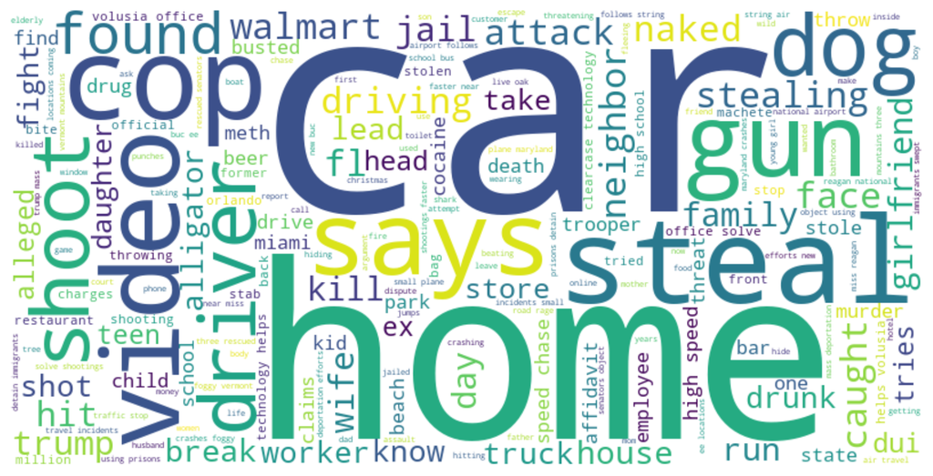

```python
from nltk.corpus import stopwords
from wordcloud import WordCloud
import matplotlib.pyplot as plt
import re
from collections import Counter

# Combine all headlines into one long string
text = " ".join(combined_new_df['headline'])

# Tokenize the words
words = re.findall(r'\b\w+\b', text.lower())  # Extract words only and convert to lowercase

# Define custom stopwords
custom_stopwords = { "charged", "say", "suspect", "gainesville", "allegedly", "officer", "deputy", "arrest", "year", "old", "officers", "convicted", "floridaman", "sheriff", "trying", "gets", "claim", "charge", "city", "petersburg"}

# Count word frequencies
word_freq = Counter(words)

# Identify the top 25 most common words
top_25_words = {word for word, _ in word_freq.most_common(25)}

# Combine both stopword sets
combined_stopwords = custom_stopwords.union(top_25_words)

# Filter words excluding combined stopwords
filtered_words = [word for word in words if word not in combined_stopwords]

# Generate word cloud with filtered words
wordcloud = WordCloud(width=800, height=400, background_color='white').generate(" ".join(filtered_words))

# Display the word cloud
plt.figure(figsize=(12, 6))
plt.imshow(wordcloud, interpolation='bilinear')
plt.axis("off")
plt.show()
```

The word cloud highlights that the crime section predominantly features stories about theft, high-speed chases, violent crimes involving weapons, youth-related incidents, and drug offenses.

### Bigram Analysis - “steal”

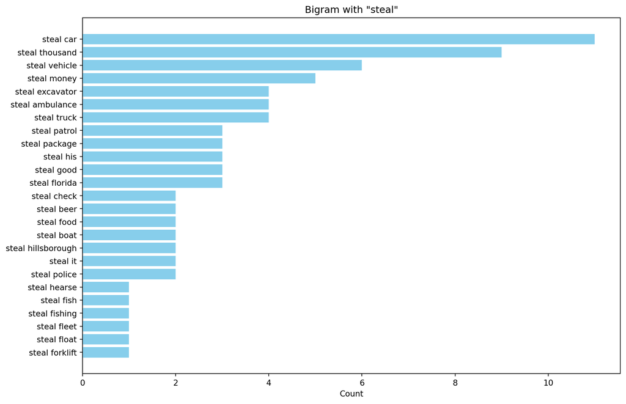

```python
import re
import spacy
from collections import Counter
import pandas as pd
import matplotlib.pyplot as plt
from sklearn.feature_extraction.text import CountVectorizer

# Load Spacy model for lemmatization
nlp = spacy.load("en_core_web_sm")

# Combine all headlines into one string
text = " ".join(combined_new_df['headline'])

# Tokenize and lemmatize words
doc = nlp(text.lower())
lemmatized_words = [token.lemma_ for token in doc if token.is_alpha]

# Create bigrams
vectorizer = CountVectorizer(ngram_range=(2, 2))
X = vectorizer.fit_transform([" ".join(lemmatized_words)])

# Get bigram counts
bigram_counts = pd.DataFrame(X.toarray(), columns=vectorizer.get_feature_names_out()).sum().sort_values(ascending=False)

# Define stopwords to filter out
stopwords = {'man', 'woman', 'after', 'and', 'by', 'at', 'of', 'to', 'in', 'about', 'the', 'from', 'tampa', 'with', 'over'}

# Filter bigrams containing the word 'steal'
steal_bigrams = bigram_counts[bigram_counts.index.str.contains(r'^steal\b', case=False)]

# Remove bigrams with stopwords
filtered_steal_bigrams = steal_bigrams[~steal_bigrams.index.str.split().map(lambda x: any(word in stopwords for word in x))]

# Convert to DataFrame for visualization
steal_df = pd.DataFrame(filtered_steal_bigrams).reset_index()
steal_df.columns = ['Bigram', 'Count']

# Limit to top 25
top_25_steal_df = steal_df.head(25)

# Visualize the co-occurrence
plt.figure(figsize=(12, 8))
plt.barh(top_25_steal_df['Bigram'], top_25_steal_df['Count'], color='skyblue')
plt.xlabel('Count')
plt.title('Bigram with "steal"')
plt.gca().invert_yaxis()

# Save the plot with a transparent background
plt.savefig("steal_cooccurrence.png", transparent=True, dpi=300)
plt.show()
```

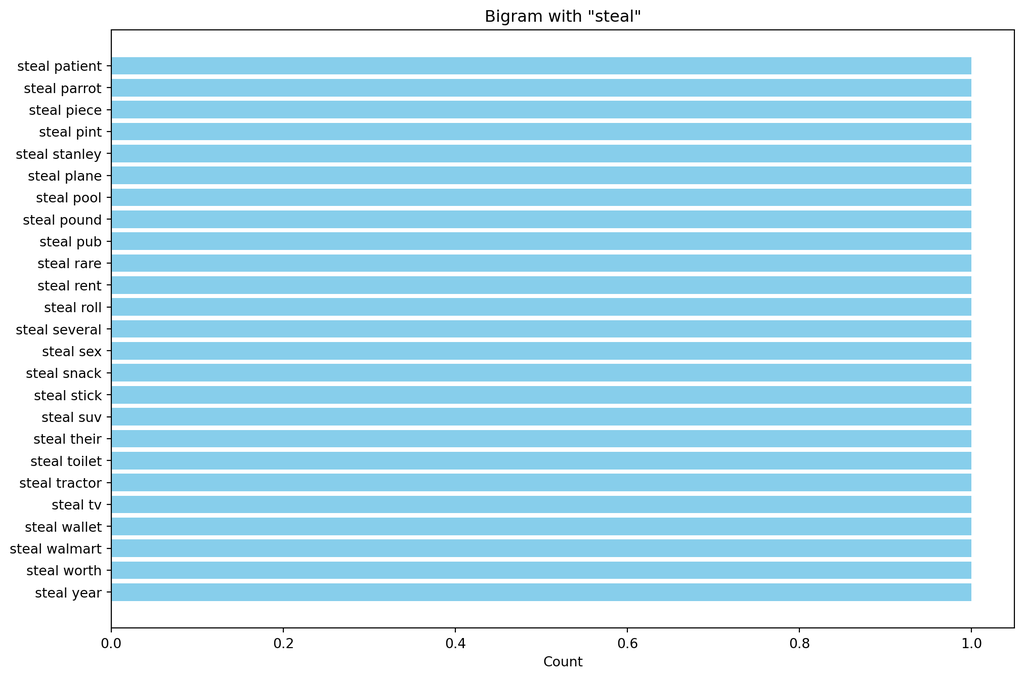

```python
# last 25
last_25 = steal_df.tail(25)
plt.figure(figsize=(12, 8))
plt.barh(last_25['Bigram'], last_25['Count'], color='skyblue')
plt.xlabel('Count')
plt.title('Bigram with "steal"')
plt.gca().invert_yaxis()
# steal_last_25 plot
plt.savefig("steal_last25.png", transparent=True, dpi=300)
plt.show()
```

### Bigram Analysis - “attack”

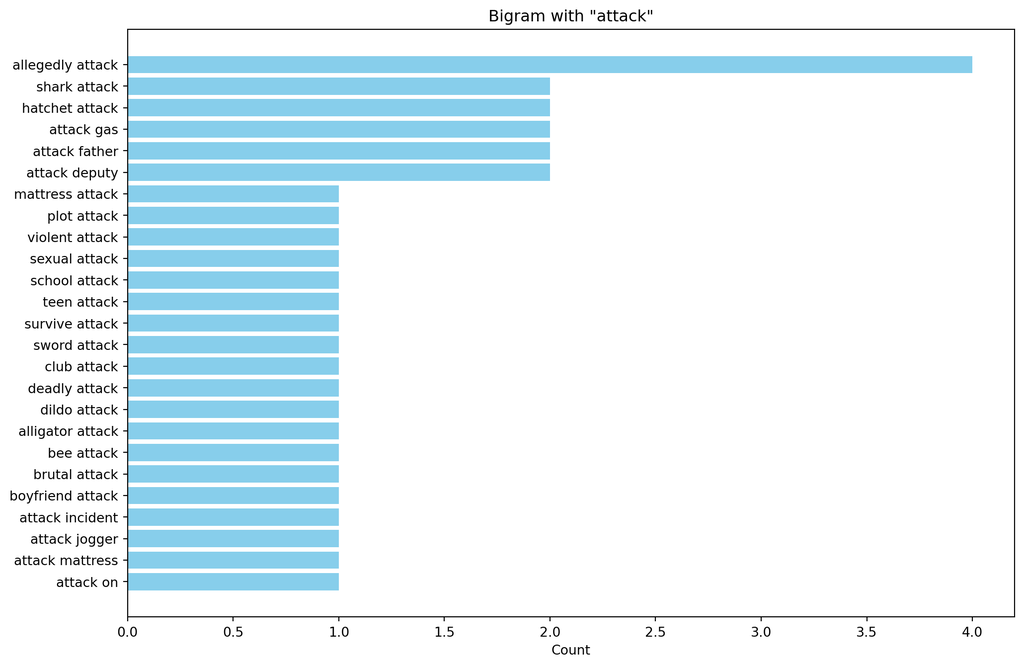

```python
import re
import spacy
from collections import Counter
import pandas as pd
import matplotlib.pyplot as plt
from sklearn.feature_extraction.text import CountVectorizer

# Load Spacy model for lemmatization
nlp = spacy.load("en_core_web_sm")

# Combine all headlines into one string
text = " ".join(combined_new_df['headline'])

# Tokenize and lemmatize words
doc = nlp(text.lower())
lemmatized_words = [token.lemma_ for token in doc if token.is_alpha]

# Create n-grams (bigrams)
vectorizer = CountVectorizer(ngram_range=(2, 2))
X = vectorizer.fit_transform([" ".join(lemmatized_words)])

# Get bigram counts
bigram_counts = pd.DataFrame(X.toarray(), columns=vectorizer.get_feature_names_out()).sum().sort_values(ascending=False)

# Define stopwords to filter out
stopwords = {'man', 'woman', 'after', 'and', 'by', 'at', 'of', 'to', 'in', 'about', 'the', 'from', 'tampa', 'with', 'over'}

# Filter bigrams containing the word 'attack'
attack_bigrams = bigram_counts[bigram_counts.index.str.contains(r'\battack\b', case=False)]

# Remove bigrams with stopwords
filtered_attack_bigrams = attack_bigrams[~attack_bigrams.index.str.split().map(lambda x: any(word in stopwords for word in x))]

# Convert to DataFrame for visualization
attack_df = pd.DataFrame(filtered_attack_bigrams).reset_index()
attack_df.columns = ['Bigram', 'Count']

# Limit to top 25
top_25_attack_df = attack_df.head(25)

# Visualize the co-occurrence
plt.figure(figsize=(12, 8))
plt.barh(top_25_attack_df['Bigram'], top_25_attack_df['Count'], color='skyblue')
plt.xlabel('Count')
plt.title('Bigram with "attack"')
plt.gca().invert_yaxis()

# Save the plot with a transparent background
plt.savefig("attack_cooccurrence.png", transparent=True, dpi=300)
plt.show()
```

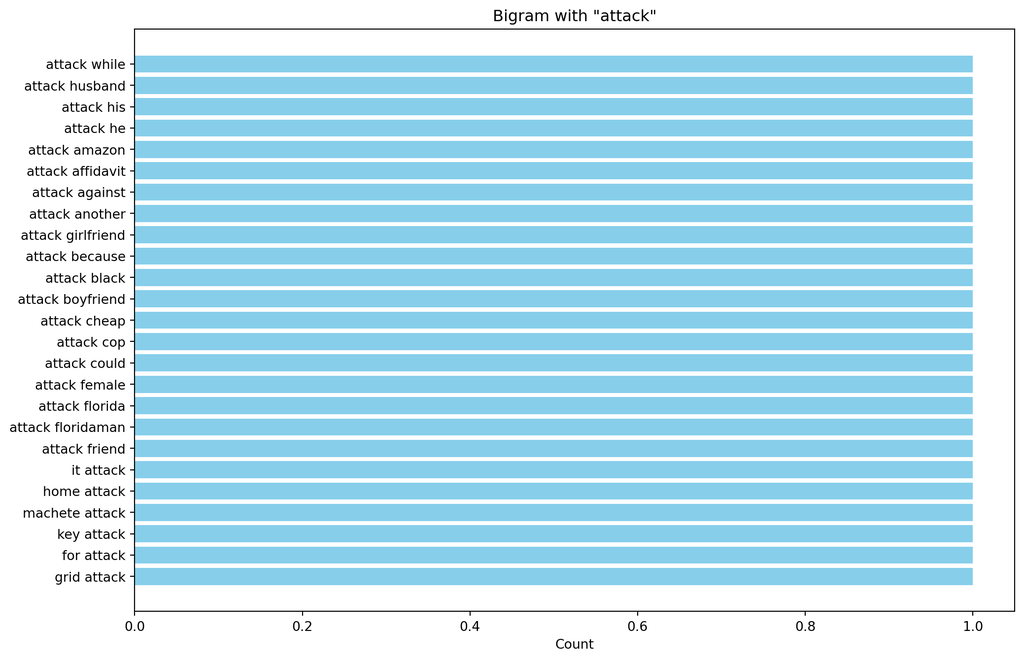

```python
# last 25
last_25 = attack_df.tail(25)
plt.figure(figsize=(12, 8))
plt.barh(last_25['Bigram'], last_25['Count'], color='skyblue')
plt.xlabel('Count')
plt.title('Bigram with "attack"')
plt.gca().invert_yaxis()
# steal_last_25 plot
plt.savefig("attack_last25.png", transparent=True, dpi=300)
plt.show()
```

### Bigram Analysis - “golf”

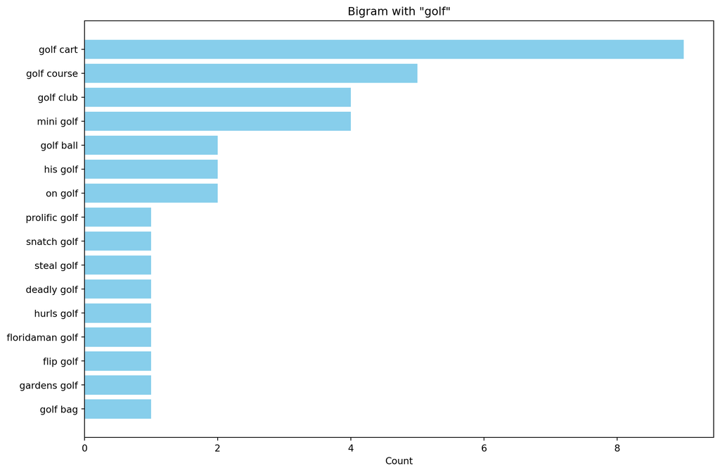

```python
import re
import spacy
from collections import Counter
import pandas as pd
import matplotlib.pyplot as plt
from sklearn.feature_extraction.text import CountVectorizer

# Load Spacy model for lemmatization
nlp = spacy.load("en_core_web_sm")

# Combine all headlines into one string
text = " ".join(combined_new_df['headline'])

# Tokenize and lemmatize words
doc = nlp(text.lower())
lemmatized_words = [token.lemma_ for token in doc if token.is_alpha]

# Create n-grams (bigrams)
vectorizer = CountVectorizer(ngram_range=(2, 2))
X = vectorizer.fit_transform([" ".join(lemmatized_words)])

# Get bigram counts
bigram_counts = pd.DataFrame(X.toarray(), columns=vectorizer.get_feature_names_out()).sum().sort_values(ascending=False)

# Define stopwords to filter out
stopwords = {'man', 'woman', 'after', 'and', 'by', 'at', 'of', 'to', 'in', 'about', 'the', 'from', 'tampa', 'with', 'over'}

# Filter bigrams containing the word 'attack'
golf_bigrams = bigram_counts[bigram_counts.index.str.contains(r'\bgolf\b', case=False)]

# Remove bigrams with stopwords
filtered_golf_bigrams = golf_bigrams[~golf_bigrams.index.str.split().map(lambda x: any(word in stopwords for word in x))]

# Convert to DataFrame for visualization
golf_df = pd.DataFrame(filtered_golf_bigrams).reset_index()
golf_df.columns = ['Bigram', 'Count']

# Limit to top 20
top_20_golf_df = golf_df.head(20)

# Visualize the co-occurrence
plt.figure(figsize=(12, 8))
plt.barh(top_20_golf_df['Bigram'], top_20_golf_df['Count'], color='skyblue')
plt.xlabel('Count')
plt.title('Bigram with "golf"')
plt.gca().invert_yaxis()

# Save the plot with a transparent background
plt.savefig("golf_cooccurrence.png", transparent=True, dpi=300)
plt.show()
```

```python
# Filter headlines containing "golf cart"
golf_cart_headlines = combined_new_df[combined_new_df['headline'].str.contains(r'\bgolf cart\b', case=False, na=False)]
```

### Topic Modeling

```python
import spacy
from nltk.corpus import stopwords
from collections import Counter
from sklearn.feature_extraction.text import CountVectorizer
from sklearn.decomposition import LatentDirichletAllocation
import pandas as pd
import re

# Load spaCy model for lemmatization
nlp = spacy.load("en_core_web_sm")

# Function to tokenize, lemmatize, and remove stopwords
def preprocess_text(text):
    doc = nlp(text.lower())  # Convert to lowercase and process with spaCy
    return [token.lemma_ for token in doc if token.is_alpha and token.lemma_ not in combined_stopwords]

# Define custom stopwords
custom_stopwords = {
    "charge", "say", "suspect", "gainesville", "allegedly", "officer",
    "deputy", "arrest", "year", "old", "convict",
    "floridaman", "sheriff", "try", "claim", "petersburg", "alachua", "marion", "city", "state", "accuse", "get", "live", "columbia", "find"
}

# Identify the top 25 most common words
text = " ".join(combined_new_df['headline'])
words = re.findall(r'\b\w+\b', text.lower())
word_freq = Counter(words)
top_25_words = {word for word, _ in word_freq.most_common(25)}

# Combine stopwords (custom + top 25 frequent words + NLTK stopwords)
combined_stopwords = set(custom_stopwords).union(top_25_words).union(set(stopwords.words('english')))

# Apply lemmatization and stopword filtering
combined_new_df['lemmatized'] = combined_new_df['headline'].apply(lambda x: " ".join(preprocess_text(x)))

# Prepare text data using CountVectorizer
vectorizer = CountVectorizer(stop_words=list(combined_stopwords), lowercase=True)
X = vectorizer.fit_transform(combined_new_df['lemmatized'])  # Use lemmatized text

# Perform LDA with 5 topics
lda = LatentDirichletAllocation(n_components=4, random_state=42)
lda.fit(X)

# Function to display top words per topic
def display_topics(model, feature_names, num_top_words):
    topics = []
    for topic_idx, topic in enumerate(model.components_):
        top_words = ", ".join([feature_names[i] for i in topic.argsort()[:-num_top_words - 1:-1]])
        topics.append([f"Topic {topic_idx + 1}", top_words])
    return pd.DataFrame(topics, columns=["Topic", "Words"])

# Create and display topic DataFrame
topics_df = display_topics(lda, vectorizer.get_feature_names_out(), 10)
pd.set_option('display.max_colwidth', None)
display(topics_df)
```

|  | Topic | Words |
| --- | --- | --- |
| 0 | Topic 1 | car, crash, steal, child, driver, home, time, jail, face, help |
| 1 | Topic 2 | steal, use, kill, new, shoot, attack, alligator, know, trump, national |
| 2 | Topic 3 | shoot, gun, drive, car, threaten, chase, kill, high, trump, ocala |
| 3 | Topic 4 | steal, shoot, run, dog, rescue, hit, sentence, sexual, ocala, catch |

### Headline Generation

```python
import random

def generate_funny_headline():
    # Set up Lists of words extracted from topic modeling, bigrams, and word cloud
    locations = ["Walmart", "TJ Maxx", "Home", "Park", "Restaurant", "Gas Station", "Bar"]
    actions = pd.concat([attack_df, steal_df])['Bigram'].tolist()
    objects = ["golf cart", "excavator", "police car", "ambulance", "Christmas Tree"]
    reasons = [
        "refuses to let him sing",
        "says he was late to a golf tournament",
        "wanted to impress his pet alligator",
        "because he was bored",
        "was attempting to time-travel to the 1800s",
        "wanted to prove Florida has the best crime stories",
    ]

    # Construct the headline
    headline = f"man {random.choice(actions)} with {random.choice(objects)}, {random.choice(reasons)} at {random.choice(locations)}"
    return headline

# Generate 5 headlines
headlines = [generate_funny_headline() for _ in range(5)]
for idx, headline in enumerate(headlines, 1):
    print(f"{idx}. {headline}")
```

```
1. man it attack with excavator, because he was bored at Park
2. man steal suv with ambulance, was attempting to time-travel to the 1800s at Park
3. man attack cheap with ambulance, says he was late to a golf tournament at TJ Maxx
4. man hatchet attack with Christmas Tree, wanted to prove Florida has the best crime stories at Walmart
5. man steal beer with excavator, was attempting to time-travel to the 1800s at Gas Station
```

## Results

The analysis of Florida Man headlines revealed several recurring themes. Some patterns are expected and some patterns are unexpected. The word cloud visualization, bigram analysis, and topic models highlighted the themes of reckless behavior and unpredictable wildlife interactions. Additionally, headline generation based on our findings produced absurd yet surprisingly realistic Florida Man scenarios, closely mimicking real-life news stories.

## Discussion

The Florida Man phenomenon has long been a source of internet fascination, often seen as an exaggerated stereotype of bizarre crime stories. However, our analysis suggests that this pattern is not just an online meme but a recurring trend supported by real data. Regardless, the Florida Man legend remains alive and well, continuing to provide some of the most entertaining and bewildering news stories in the US.